# Modelli a componenti non osservabili (UCM: Unobserved Component Models)

$$Y_t= \mu_t+\gamma_t+\psi_t + \epsilon_t \\.\\
Dove: \\
\mu_t = trend \\
\gamma_t = stagionalità \\
\psi_t = ciclo \\
\epsilon_t = rumore$$

Quattro componenti di base di questi modelli:

- Trend: livello medio della serie storica al tempo t;
- Stagionalità: potrebbe essercene più di una, ad es. stagionalità legata all’ora del giorno o al giorno della settimana o al mese dell’anno;
- Ciclo: di solito modella il ciclo economico ma può servire anche per serie non economiche;
- Rumore (WN): è ciò che resta fuori dalle altre componenti e non dovrebbe avere memoria.

Per questo argomento useremo la serie storiche *AirPassenger*: il numero di passegeri sui voli aerei dal 1949 al 1961.

Dataset disponibile al link:

https://www.kaggle.com/rakannimer/air-passengers

```r
library(ggfortify)
AirPassengers
```

```
##      Jan Feb Mar Apr May Jun Jul Aug Sep Oct Nov Dec
## 1949 112 118 132 129 121 135 148 148 136 119 104 118
## 1950 115 126 141 135 125 149 170 170 158 133 114 140
## 1951 145 150 178 163 172 178 199 199 184 162 146 166
## 1952 171 180 193 181 183 218 230 242 209 191 172 194
## 1953 196 196 236 235 229 243 264 272 237 211 180 201
## 1954 204 188 235 227 234 264 302 293 259 229 203 229
## 1955 242 233 267 269 270 315 364 347 312 274 237 278
## 1956 284 277 317 313 318 374 413 405 355 306 271 306
## 1957 315 301 356 348 355 422 465 467 404 347 305 336
## 1958 340 318 362 348 363 435 491 505 404 359 310 337
## 1959 360 342 406 396 420 472 548 559 463 407 362 405
## 1960 417 391 419 461 472 535 622 606 508 461 390 432
```

```r
summary(AirPassengers)
```

```
##    Min. 1st Qu.  Median    Mean 3rd Qu.    Max.
##   104.0   180.0   265.5   280.3   360.5   622.0
```

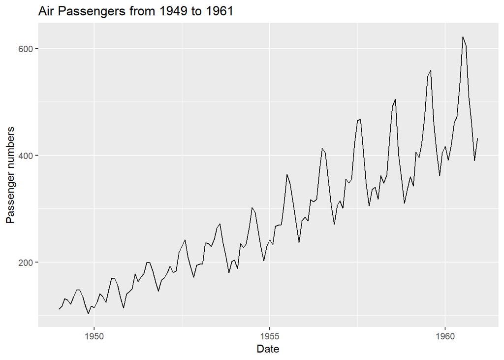

```r
autoplot(AirPassengers) + labs(x ="Date", y = "Passenger numbers", title="Air Passengers from 1949 to 1961")
```